# The `{here}` package

Fire safety, continued

## The problem with `setwd()`

- `setwd()` changes the working directory, leading to potential issues in collaboration and reproducibility
  - You and I don’t have the same file structure!
  - For example, my current working directory is

  ```r
  getwd()
  ```

  ```
  [1] "/Users/l.smith/Documents/Teaching/Emory/epi590r-2023"
  ```

- It’s also really annoying to change your working directory when you move around files and folders, even if it’s just you using them

## Do you think this code from 2015 still works?

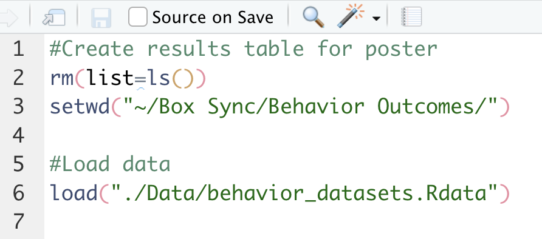

## Referring to files with the `here` package

```r
source(here::here("R", "functions.R"))

dat <- read_csv(here::here("data", "raw", "data.csv"))

p <- ggplot(dat) + geom_point(aes(x, y))

ggsave(plot = p,
       filename = here::here("results", "figures", "fig.pdf"))
```

You can also separate the file paths with `/`:

```r
dat <- read_csv(here::here("data/raw/data.csv"))
```

## How it works

- Construct file paths with reference to the top directory holding your `.Rproj` file.
- `here::here("data", "raw", "data.csv")` for me, here, becomes `"/Users/l.smith/Documents/Teaching/Emory/epi590r-2023/data/raw/data.csv"`
  - If I change my working directory to somewhere else within my project, it will still give me that path
- And if I send you my code to run, it will become whatever file path *you* need it to be, as long as you’re running it within the R Project.

## Referring to the `here` package

```r
here::here()
```

is equivalent to

```r
library(here)
here()
```

I just prefer to write out the package name whenever I need it, but you can load the package for your entire session if you want.

## Exercises

1. Install the `{here}` package:

   `install.packages("here")`
2. Make sure you’re in your in-class R project! In the console, run:

   `here::here()` to print your project directory  
   `getwd()` to print your working directory

   What do you notice?
3. In the console, run:

   `setwd("data")` to set your working directory

   Then run the same lines as above. What do you notice?

## Exercises, cont.

4. Download the next `.R` script from the website and use your file browser to put it in the R folder in your project.
- Run through the code line-by-line.
- Compare it with the code from the last section.

`15:00`